# Calibration vignette

Edward Wallace

2 Feb 2019

# Plan

This vignette shows how to use tidyqpcr functions to calibrate qPCR probes

This is real qPCR data by Edward Wallace in Feb 2019, testing new RT-qPCR primer sets against *S. cerevisiae* genes. We took exponential-phase total RNA previously extracted by Jamie Auxillos.

We tested 2-3 primer sets each for 7 genes with 2 Technical replicates as well:

- ECM38/ YLR299W (3 primer sets)
- FET5 / YFL041W (3 primer sets)
- GPT2/YKR067W
- ILV5/YLR355C
- NRD1/YNL251C (ordered 3rd primer set not tested today)
- RDL1/YOR285W
- TFS1/YLR178C

For each we do serial 5x dilutions down to 125x, a -RT and no template control. In duplicate.

## Conclude acceptable primer sets

These probes have sensible standard curves, amplification curves, melt curves. In tie-breakers we pick the more highly detected probe.

- ECM38 set 3
- FET5 set 1 or 4
- GPT2 set 4
- ILV5 set 4
- NRD1 set 1 or 2
- RDL1 set 4
- TFS1 set 1

## Label and plan plates

```r
# Names of target genes
Names <- c("ECM38","FET5","GPT2","ILV5","NRD1","RDL1","TFS1")
# ORF ids of target genes
Targets  <- c("YLR299W","YFL041W","YKR067W","YLR355C","YNL251C","YOR285W","YLR178C")
# Repeats of gene names to account for resting multiple probesets
Namesrep <- c(rep(Names[1:2],each=3),rep(Names[3:7],each=2))
# id numbers of multiple probesets (reflecting IDs as ordered)
Probes <- paste(Namesrep,
                c(1,2,3,1,3,4,1,4,1,4,1,2,4,5,1,5),sep="_")


rowkey <- data.frame(WellR=LETTERS[1:16],
                     Names=Namesrep,
                     # Targets=rep(Targets,each=2),
                     Probe=factor(Probes, levels=Probes)
)


plate1plan <-
    label_plate_rowcol(
        create_blank_plate(),
        rowkey,
        create_colkey_4dilutions_mRTNT_in24()) %>%
    mutate(Sample=paste(BioRep,DilutionNice,sep="_"))
```

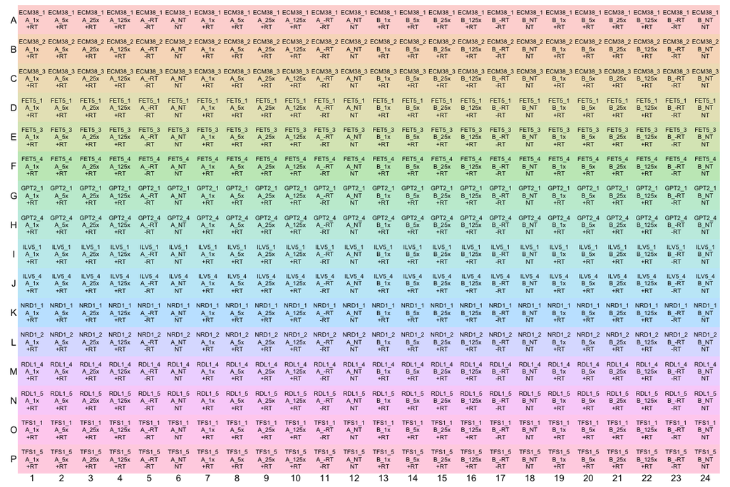

```r
display_plate(plate1plan)
```

## Load and summarize data

```r
# read my plates

plates <- read_tsv("../inst/extdata/Edward_qPCR_Nrd1_calibration_2019-02-02_Ct.txt",
                       skip=1) %>%
    mutate(Well=Pos,Ct=Cp) %>%
    right_join(plate1plan)
```

```r
plates
```

```
## # A tibble: 384 x 20
##    Include Color Pos   Name     Cp Concentration Standard Status Well
##    <lgl>   <dbl> <chr> <chr> <dbl> <lgl>            <dbl> <lgl>  <chr>
##  1 TRUE      255 A1    Samp…  22.8 NA                   0 NA     A1
##  2 TRUE      255 A2    Samp…  24.7 NA                   0 NA     A2
##  3 TRUE      255 A3    Samp…  26.8 NA                   0 NA     A3
##  4 TRUE      255 A4    Samp…  28.6 NA                   0 NA     A4
##  5 TRUE    65280 A5    Samp…  NA   NA                   0 NA     A5
##  6 TRUE    65280 A6    Samp…  NA   NA                   0 NA     A6
##  7 TRUE      255 A7    Samp…  23.2 NA                   0 NA     A7
##  8 TRUE      255 A8    Samp…  24.8 NA                   0 NA     A8
##  9 TRUE      255 A9    Samp…  26.9 NA                   0 NA     A9
## 10 TRUE    65280 A10   Samp…  NA   NA                   0 NA     A10
## # … with 374 more rows, and 11 more variables: Ct <dbl>, WellR <fct>,
## #   WellC <int>, Dilution <dbl>, DilutionNice <chr>, Type <fct>,
## #   BioRep <fct>, TechRep <fct>, Names <fct>, Probe <fct>, Sample <chr>
```

```r
summary(plates)
```

```
##  Include            Color           Pos                Name
##  Mode:logical   Min.   :  255   Length:384         Length:384
##  TRUE:384       1st Qu.:  255   Class :character   Class :character
##                 Median :  255   Mode  :character   Mode  :character
##                 Mean   :18035
##                 3rd Qu.:65280
##                 Max.   :65280
##
##        Cp        Concentration     Standard  Status
##  Min.   :13.89   Mode:logical   Min.   :0   Mode:logical
##  1st Qu.:20.55   NA's:384       1st Qu.:0   NA's:384
##  Median :23.44                  Median :0
##  Mean   :23.63                  Mean   :0
##  3rd Qu.:26.68                  3rd Qu.:0
##  Max.   :36.77                  Max.   :0
##  NA's   :105
##      Well                 Ct            WellR         WellC
##  Length:384         Min.   :13.89   A      : 24   Min.   : 1.00
##  Class :character   1st Qu.:20.55   B      : 24   1st Qu.: 6.75
##  Mode  :character   Median :23.44   C      : 24   Median :12.50
##                     Mean   :23.63   D      : 24   Mean   :12.50
##                     3rd Qu.:26.68   E      : 24   3rd Qu.:18.25
##                     Max.   :36.77   F      : 24   Max.   :24.00
##                     NA's   :105     (Other):240
##     Dilution      DilutionNice        Type     BioRep  TechRep   Names
##  Min.   :0.0080   Length:384         +RT:256   A:192   1:192   ECM38:72
##  1st Qu.:0.0400   Class :character   -RT: 64   B:192   2:192   FET5 :72
##  Median :0.6000   Mode  :character   NT : 64                   GPT2 :48
##  Mean   :0.5413                                                ILV5 :48
##  3rd Qu.:1.0000                                                NRD1 :48
##  Max.   :1.0000                                                RDL1 :48
##                                                                TFS1 :48
##      Probe        Sample
##  ECM38_1: 24   Length:384
##  ECM38_2: 24   Class :character
##  ECM38_3: 24   Mode  :character
##  FET5_1 : 24
##  FET5_3 : 24
##  FET5_4 : 24
##  (Other):240
```

# Plot unnormalized data

## -RT and NT controls are low

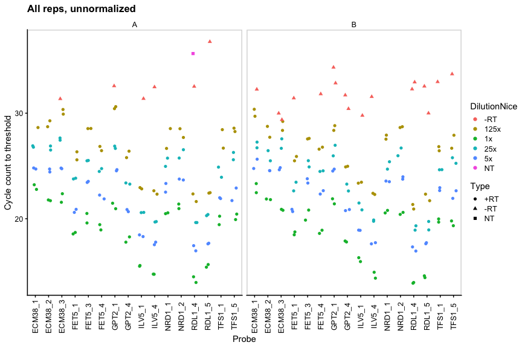

```r
ggplot(data=plates) +
    geom_point(aes(x=Probe,y=Ct,colour=DilutionNice,shape=Type),
               position=position_jitter(width = 0.2,height=0)) +
    labs(y="Cycle count to threshold",
         title="All reps, unnormalized") +
    facet_wrap(~BioRep) +
    panel_border() +
    theme(axis.text.x=element_text(angle=90,vjust=0.5))
```

## Dilution series is linear - only used Superscript IV.

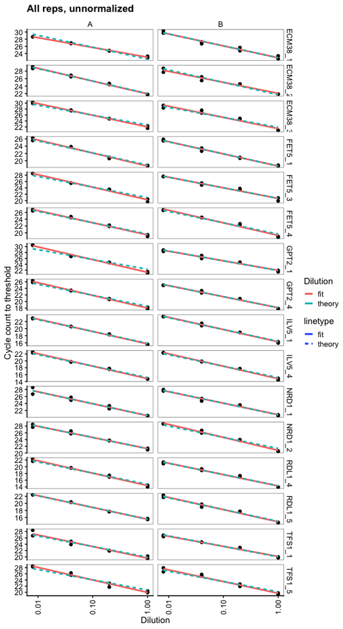

```r
ggplot(data=filter(plates,Type=="+RT"),aes(x=Dilution,y=Ct)) +
    geom_point() +
    stat_smooth(formula=y~x,method="lm",se=FALSE,
                aes(colour="fit",linetype="fit")) +
    stat_smooth(formula=y~1+offset(-x*log(10)/log(2)),method="lm",se=FALSE,
                aes(colour="theory",linetype="theory")) +
    scale_x_log10(breaks=10^-(0:3)) +
    scale_y_continuous(breaks=seq(0,30,2)) +
    labs(y="Cycle count to threshold",
         title="All reps, unnormalized",
         colour="Dilution") +
    facet_grid(Probe~BioRep,scales="free_y") +
    theme(axis.text.x=element_text(angle=90,vjust=0.5))
```

## Dilution series for nice probes only

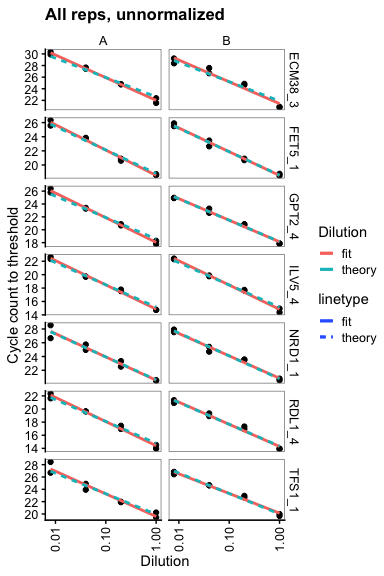

```r
Probesnice <- c("ECM38_3","FET5_1","GPT2_4","ILV5_4","NRD1_1","RDL1_4","TFS1_1")

ggplot(data=filter(plates,Type=="+RT",Probe %in% Probesnice),
       aes(x=Dilution,y=Ct)) +
    geom_point() +
    stat_smooth(formula=y~x,method="lm",se=FALSE,
                aes(colour="fit",linetype="fit")) +
    stat_smooth(formula=y~1+offset(-x*log(10)/log(2)),method="lm",se=FALSE,
                aes(colour="theory",linetype="theory")) +
    scale_x_log10(breaks=10^-(0:3)) +
    scale_y_continuous(breaks=seq(0,30,2)) +
    labs(y="Cycle count to threshold",
         title="All reps, unnormalized",
         colour="Dilution") +
    facet_grid(Probe~BioRep,scales="free_y") +
    theme(axis.text.x=element_text(angle=90,vjust=0.5))
```

## Load raw data for amplification and curves.

```r
plate1curve <- read_tsv("../inst/extdata/Edward_qPCR_Nrd1_calibration_2019-02-02.txt",
                       skip=2,
                        col_names=c("Well","SID","Program","Segment",
                                    "Cycle","Time","Temperature","Fluor")
                      ) %>%
    debaseline() %>%
    left_join(plate1plan)

# amplification curve is program 2
platesamp  <- plate1curve %>%
  filter(Program == 2)

# melt curve is program 3 or 4, depending on cycle
platesmelt <- plate1curve %>%
  filter(Program > 2) %>%
  demelt() %>%
  filter(Temperature >= 61)
```

### Plot de-baseline’d raw data for single well

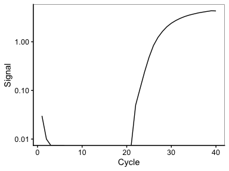

```r
ggplot(data=platesamp %>% filter(Well=="A1"),
       aes(x=Cycle,y=Signal)) +
    geom_line() +
    scale_y_log10()
```

### Plot all amplification curves

```r
plate1plan %>%
           filter(TechRep=="1",Probe==Probes[1],DilutionNice=="1x")
```

```
##   WellR WellC Well Dilution DilutionNice Type BioRep TechRep Names   Probe
## 1     A     1   A1        1           1x  +RT      A       1 ECM38 ECM38_1
## 2     A    13  A13        1           1x  +RT      B       1 ECM38 ECM38_1
##   Sample
## 1   A_1x
## 2   B_1x
```

```r
plate1plan %>%
           filter(TechRep=="2",Probe==Probes[1],DilutionNice=="1x")
```

```
##   WellR WellC Well Dilution DilutionNice Type BioRep TechRep Names   Probe
## 1     A     7   A7        1           1x  +RT      A       2 ECM38 ECM38_1
## 2     A    19  A19        1           1x  +RT      B       2 ECM38 ECM38_1
##   Sample
## 1   A_1x
## 2   B_1x
```

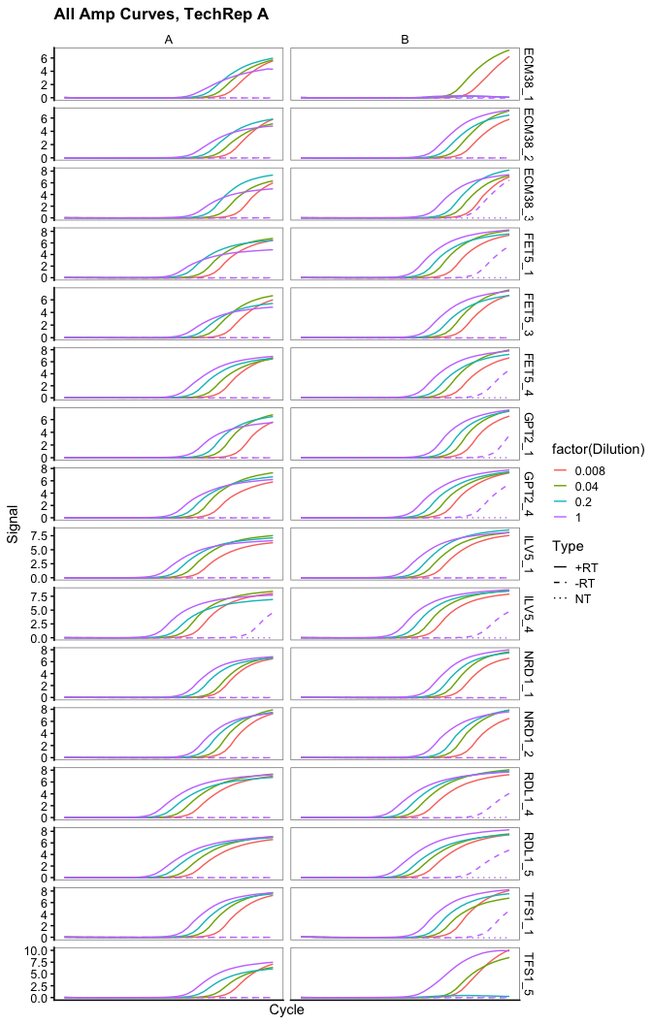

```r
ggplot(data=platesamp %>%
           filter(TechRep=="1"),
       aes(x=Cycle,y=Signal,colour=factor(Dilution),linetype=Type)) +
    facet_grid(Probe~BioRep,scales="free_y") +
    scale_linetype_manual(values=c("+RT"="solid","-RT"="dashed","NT"="dotted")) +
    geom_line() +
    scale_x_continuous(breaks=seq(60,100,10),minor_breaks=seq(60,100,5)) +
    labs(title="All Amp Curves, TechRep A")
```

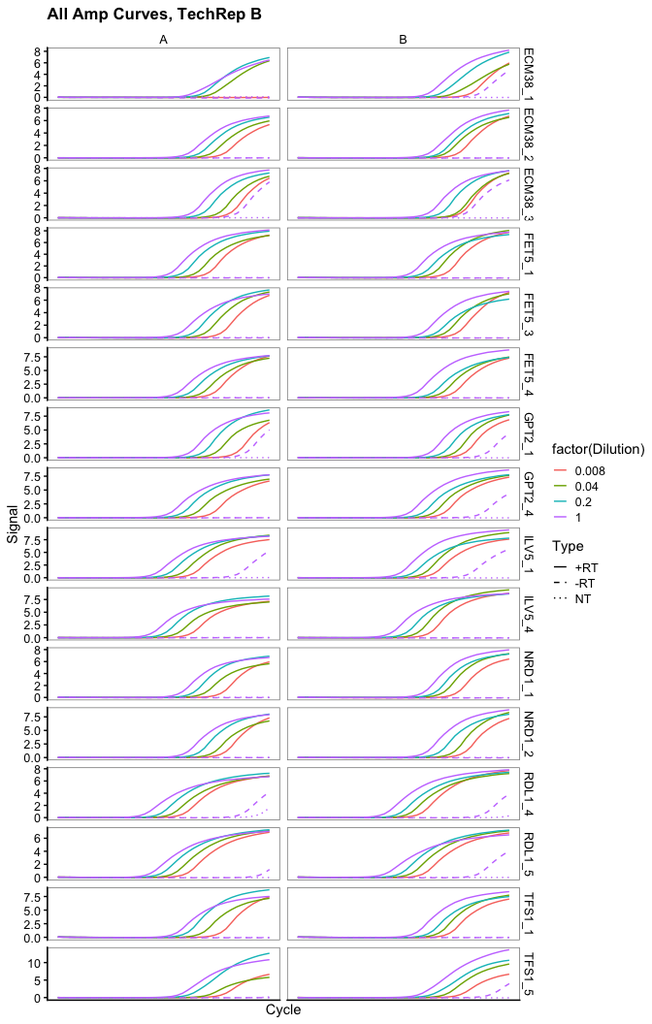

```r
ggplot(data=platesamp %>%
           filter(TechRep=="2"),
       aes(x=Cycle,y=Signal,colour=factor(Dilution),linetype=Type)) +
    facet_grid(Probe~BioRep,scales="free_y") +
    scale_linetype_manual(values=c("+RT"="solid","-RT"="dashed","NT"="dotted")) +
    geom_line() +
    scale_x_continuous(breaks=seq(60,100,10),minor_breaks=seq(60,100,5)) +
    labs(title="All Amp Curves, TechRep B")
```

Here it would be sensible to also estimate the probe efficiency.

## Plot melt curve

### Plot melt curve for single well

```r
ggplot(data=platesmelt %>%
           filter(Well=="A1"),
       aes(x=Temperature,y=dRdT)) +
    facet_wrap(~Probe) +
    geom_line()
```

[output not shown]

### Plot all melt curves

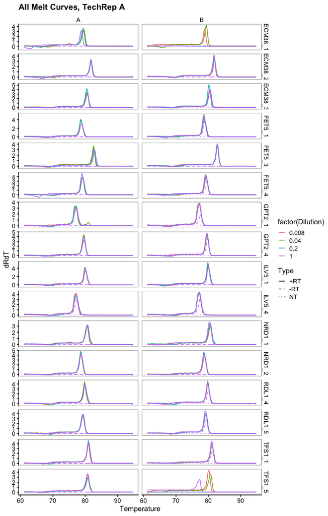

```r
ggplot(data=platesmelt %>%
           filter(TechRep=="1"),
       aes(x=Temperature,y=dRdT,colour=factor(Dilution),linetype=Type)) +
    facet_grid(Probe~BioRep,scales="free_y") +
    scale_linetype_manual(values=c("+RT"="solid","-RT"="dashed","NT"="dotted")) +
    geom_line() +
    scale_x_continuous(breaks=seq(60,100,10),minor_breaks=seq(60,100,5)) +
    labs(title="All Melt Curves, TechRep A")
```

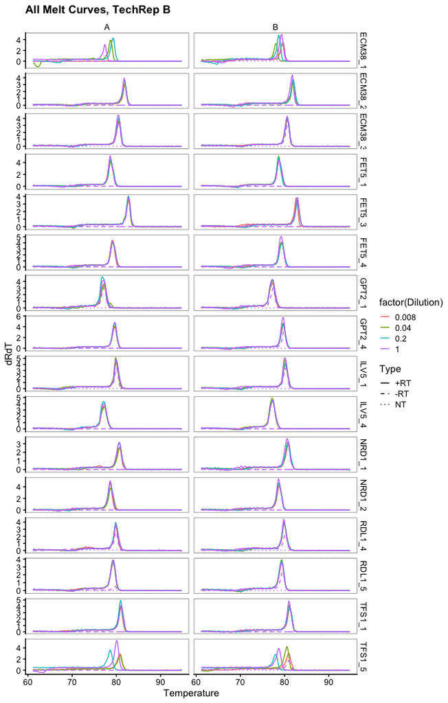

```r
ggplot(data=platesmelt %>%
           filter(TechRep=="2"),
       aes(x=Temperature,y=dRdT,colour=factor(Dilution),linetype=Type)) +
    facet_grid(Probe~BioRep,scales="free_y") +
    scale_linetype_manual(values=c("+RT"="solid","-RT"="dashed","NT"="dotted")) +
    geom_line() +
    scale_x_continuous(breaks=seq(60,100,10),minor_breaks=seq(60,100,5)) +
    labs(title="All Melt Curves, TechRep B")
```

### Plot only zoomed melt curves for Superscript

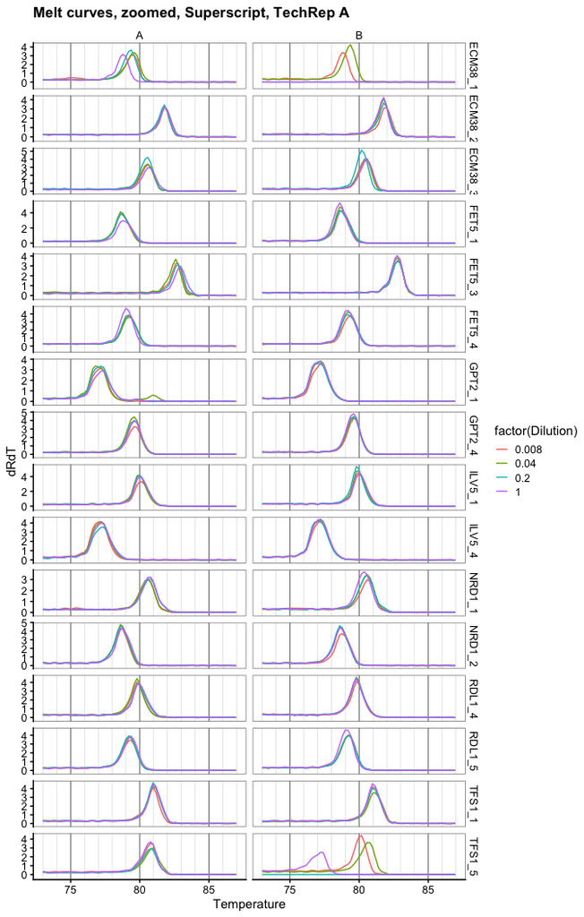

```r
ggplot(data=platesmelt %>%
           filter(TechRep=="1",Type=="+RT"),
       aes(x=Temperature,y=dRdT,colour=factor(Dilution))) +
    facet_grid(Probe~BioRep,scales="free_y") +
    geom_line() +
    scale_x_continuous(breaks=seq(60,100,5),minor_breaks=seq(60,100,1),
                       limits=c(73,87)) +
    labs(title="Melt curves, zoomed, Superscript, TechRep A") +
    theme(panel.grid.major.x=element_line(colour="grey50",size=0.4),
          panel.grid.minor.x=element_line(colour="grey70",size=0.1))
```

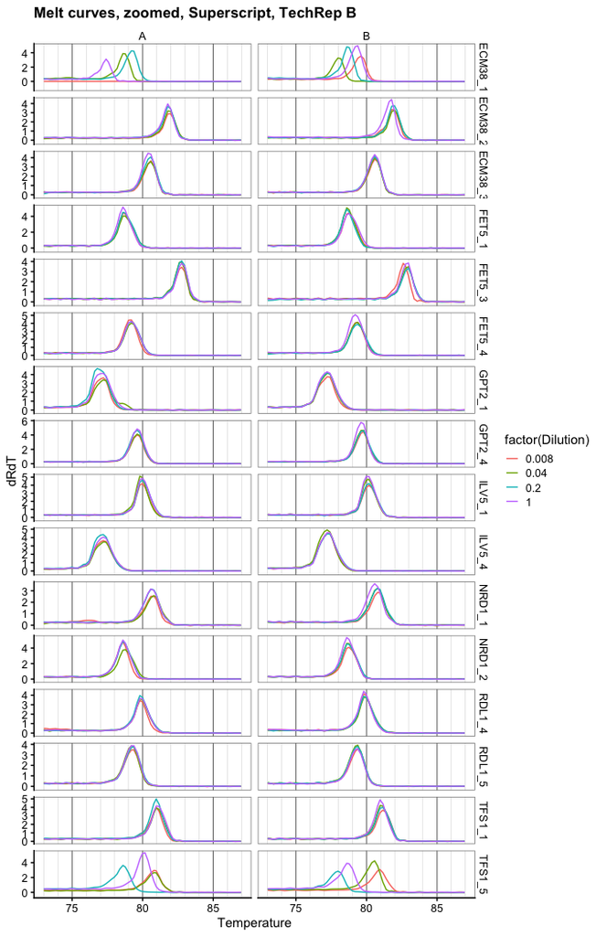

```r
ggplot(data=platesmelt %>%
           filter(TechRep=="2",Type=="+RT"),
       aes(x=Temperature,y=dRdT,colour=factor(Dilution))) +
    facet_grid(Probe~BioRep,scales="free_y") +
    geom_line() +
    scale_x_continuous(breaks=seq(60,100,5),minor_breaks=seq(60,100,1),
                       limits=c(73,87)) +
    labs(title="Melt curves, zoomed, Superscript, TechRep B") +
    theme(panel.grid.major.x=element_line(colour="grey50",size=0.4),
          panel.grid.minor.x=element_line(colour="grey70",size=0.1))
```

### Plot only zoomed melt curves for nice probes

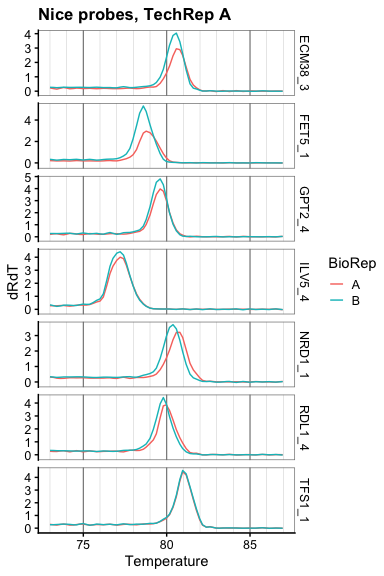

```r
Probesnice <- c("ECM38_3","FET5_1","GPT2_4","ILV5_4","NRD1_1","RDL1_4","TFS1_1")
ggplot(data=platesmelt %>%
           filter(TechRep=="1",Type=="+RT",DilutionNice=="1x",
                  Probe %in% Probesnice),
       aes(x=Temperature,y=dRdT,colour=BioRep)) +
    facet_grid(Probe~.,scales="free_y") +
    geom_line() +
    scale_x_continuous(breaks=seq(60,100,5),minor_breaks=seq(60,100,1),
                       limits=c(73,87)) +
    labs(title="Nice probes, TechRep A") +
    theme(panel.grid.major.x=element_line(colour="grey50",size=0.4),
          panel.grid.minor.x=element_line(colour="grey70",size=0.1))
```